# STAT547M-hw10-An-Byeongchan

## Overview

I explore `Alpha Vantage API` which has realtime and historical data on stocks, physical currencies, and digital/crypto currencies.

In this hw10, I will follow the data analysis I did in hw07 (link to hw07 03_report.md). I calculated the stock performances of Apple and Amazon.com in 2016 in hw07. I provided cumulative return on AAPL (Apple) and AMZN (Amazon.com) in 2016. Cumulative returns are buy-and-hold returns which show the cumulative return at a specific point when a unit amount ($1) is invested in the beginning of the period.

In this hw10, I will have look at digital and crypto currencies such as BTC(Bitcoin), ETH(Ethereum), XRP(Ripples) as the datasets are availalbe on `Alpha Vantage API`. In addition, I will compare these with Apple’s stock performance (cumulative return).

## Stock performance (Apple)

`Alpha Vantage API` provides a variety of stock time series data: Intraday, Daily (adjusted), Weekly (adjusted), and Monthly (adjusted). I made a function which can extract daily adjusted dataset and monthly adjusted dataset.

- `stock_data(symbol = symbol, interval = interval, outputsize = outputsize)`.
  - Symbol is each firm’s ticker symbol.
  - interval is either “MONTHLY” or “DAILY” (They should be UPPER CASE!!)
  - outputsize has two values ‘full’ and ‘compact’: ‘compact’ returns only the latest 100 data points; ‘full’ returns the full-length time series of up to 20 years of historical data. Those datasets have open, high, low, and close prices, volume, and dividend amount. `Adjusted price` is adjusting for dividend payments.

```r
#install.packages("httr")
library(httr)
library(jsonlite)
library(purrr)
library(glue)
library(tidyverse)
```

```r
#test <- GET("https://www.alphavantage.co/query?function=TIME_SERIES_MONTHLY_ADJUSTED&symbol=AAPL&apikey=RON9A5RW8SKDN593")
#test2 <- fromJSON("https://www.alphavantage.co/query?function=TIME_SERIES_MONTHLY_ADJUSTED&symbol=AAPL&apikey=RON9A5RW8SKDN593")


#stock_data to get the stock data (monthly or daily data)
# (Monthly or Daily) Adjusted Prices and Volumes
# symbol: Ticker symbol
# interval: 'MONTHLY' or 'DAILY' (MUST BE UPPER CASE!!!)
# outputsize: 'full' or 'compact' ('compact' prints recent 100 observations)
stock_data <- function(symbol = symbol, interval = interval, outputsize = outputsize){
    my_url <- glue('https://www.alphavantage.co/query?function=TIME_SERIES_{interval}_ADJUSTED&symbol={symbol}&outputsize={outputsize}&apikey=RON9A5RW8SKDN593')

    stock_dt <- fromJSON(my_url)
    if (interval == "MONTHLY") stock_dt2 <- stock_dt[["Monthly Adjusted Time Series"]]
    else if (interval == "DAILY") stock_dt2 <- stock_dt[["Time Series (Daily)"]]
    else stop('interval only takes 2 strings: "MONTHLY" or "DAILY"')

    stock_dt3 <- map_df(stock_dt2,`[`, c("1. open",
                                                                             "2. high",
                                                                             "3. low",
                                                                             "4. close",
                                                                             "5. adjusted close",
                                                                             "6. volume",
                                                                             "7. dividend amount"))
    stock_dt3 <- lapply(stock_dt3, function(x) as.numeric(x)) %>%
        as.data.frame()
    stock_dt3['date'] <- names(stock_dt2)
    stock_dt3['symbol'] <- symbol
    stock_dt3$date <- as.Date(stock_dt3$date, format = "%Y-%m-%d")

    stock_dt3 <- stock_dt3 %>%
        select(symbol, date,
                     X5..adjusted.close, X6..volume) %>%
        rename(prc = X5..adjusted.close,
                     volume = X6..volume)

    return(stock_dt3)
}
```

I extracted Apple’s stock data (from Jan 1 2017 to Dec 5 2017)

```r
AAPL <- stock_data(symbol = "AAPL", interval = "DAILY", outputsize = 'full') %>%
    filter(date>="2017-01-01" & date <= "2017-12-05" )

knitr::kable(head(AAPL), format = "markdown")
```

| symbol | date | prc | volume |
| --- | --- | --- | --- |
| AAPL | 2017-12-05 | 169.64 | 27008428 |
| AAPL | 2017-12-04 | 169.80 | 32115052 |
| AAPL | 2017-12-01 | 171.05 | 39590080 |
| AAPL | 2017-11-30 | 171.85 | 41484363 |
| AAPL | 2017-11-29 | 169.48 | 41456722 |
| AAPL | 2017-11-28 | 173.07 | 25468442 |

## Digital and crypto currencies performance (BTC(Bitcoin), ETH(Ethereum), XRP(Ripples))

`Alpha Vantage API` also provides Digital and crypto currencies data. I made a function which can extract those data.  
- `digi_cur(symbol = symbol)`. - Symbol is each currency’s symbol. (eg. BTC(Bitcoin), ETH(Ethereum), XRP(Ripples)) This dataset has open, high, low, and close prices, volume, and market cap(price*volume).

```r
# digi_cur to get the daily data for digital and crypto currencies such as Bitcoin)
#Daily prices and volumes for Digital Currency

# symbol: The digital/crypto currency of your choice such as BTC(Bitcoin), ETH(Ethereum), XRP(Ripples)
# outputsize: 'full' or 'compact' ('compact' prints recent 100 observations)
digi_cur <- function(symbol = symbol){
    my_url <- glue('https://www.alphavantage.co/query?function=DIGITAL_CURRENCY_DAILY&symbol={symbol}&market=USD&apikey=RON9A5RW8SKDN593')

    digi_curr <- fromJSON(my_url)
  digi_curr2 <- digi_curr[["Time Series (Digital Currency Daily)"]]

    digi_curr3 <- map_df(digi_curr2,`[`, c("1a. open (USD)", "1b. open (USD)",
                                                                                 "2a. high (USD)", "2b. high (USD)",
                                                                               "3a. low (USD)", "3b. low (USD)",
                                                                                 "4a. close (USD)", "4b. close (USD)",
                                                                                 "5. volume",
                                                                                 "6. market cap (USD)"))
    digi_curr3 <- lapply(digi_curr3, function(x) as.numeric(x)) %>%
        as.data.frame()
    digi_curr3['date'] <- names(digi_curr2)
    digi_curr3['symbol'] <- symbol
    digi_curr3$date <- as.Date(digi_curr3$date, format = "%Y-%m-%d")

    digi_curr3 <- digi_curr3 %>%
        select(symbol, date,
                     X4a..close..USD., X5..volume, X6..market.cap..USD.) %>%
        rename(prc = X4a..close..USD.,
                     volume = X5..volume,
                     mktcap = X6..market.cap..USD.)

    return(digi_curr3)
}


# Get BTC(Bitcoin), ETH(Ethereum), XRP(Ripples) data
# I will choose the data from Jan 1 to Dec 5
btc <- digi_cur('btc') %>% filter(date >= "2017-01-01" & date <= "2017-12-05")
eth <- digi_cur('eth') %>% filter(date >= "2017-01-01" & date <= "2017-12-05")
xrp <- digi_cur('xrp') %>% filter(date >= "2017-01-01" & date <= "2017-12-05")
knitr::kable(tail(eth), format = "markdown")
```

|  | symbol | date | prc | volume | mktcap |
| --- | --- | --- | --- | --- | --- |
| 334 | eth | 2017-01-06 | 10.058127 | 346575.8 | 3485904 |
| 335 | eth | 2017-01-05 | 10.152173 | 901449.2 | 9151669 |
| 336 | eth | 2017-01-04 | 11.002356 | 717888.4 | 7898463 |
| 337 | eth | 2017-01-03 | 9.531111 | 648583.1 | 6181717 |
| 338 | eth | 2017-01-02 | 8.232979 | 266461.0 | 2193768 |
| 339 | eth | 2017-01-01 | 8.036445 | 294315.4 | 2365250 |

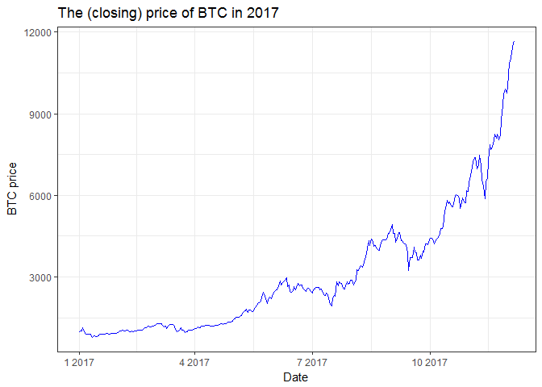

```r
btc %>%
    ggplot(aes(x= date, y= prc)) +
  geom_line(color = "blue") +
  theme_bw() +
  labs(x="Date",
       y="BTC price",
       title = "The (closing) price of BTC in 2017")
```

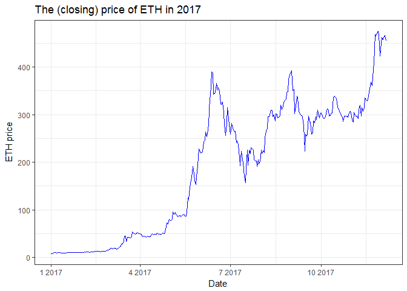

```r
eth %>%
    ggplot(aes(x= date, y= prc)) +
  geom_line(color = "blue") +
  theme_bw() +
  labs(x="Date",
       y="ETH price",
       title = "The (closing) price of ETH in 2017")
```

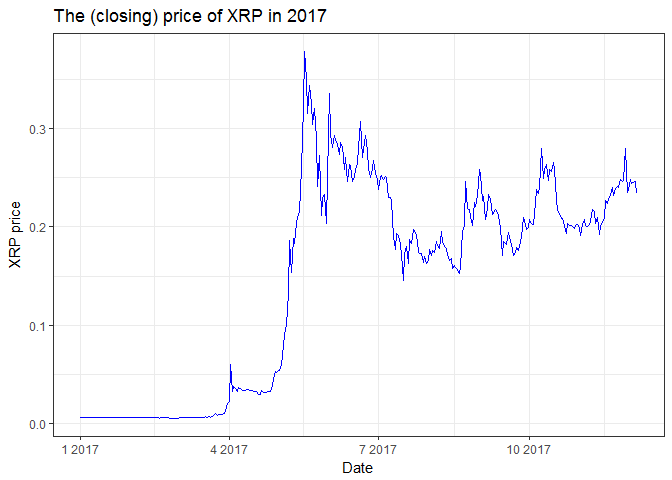

```r
xrp %>%
    ggplot(aes(x= date, y= prc)) +
  geom_line(color = "blue") +
  theme_bw() +
  labs(x="Date",
       y="XRP price",
       title = "The (closing) price of XRP in 2017")
```

I extracted each currency’s data (from Jan 1 2017 to Dec 5 2017) and I added plots for each currency’s closing prices.  
I made a function to calculate daily returns and cumulative returns. The tail of `cum_ret_coins` shows their cumulative returns on December when they invested unit amount ($1) on Jan 1 2017.The result is quite amazing! Given that you invested 1 dollar in each currency (Jan 1 2017), you will get 11.8 in Bitcoin, 56.5 in Ethereum, 36.5 in Ripples (Dec 5 2017)!! Cumulative returns are 1180%, 5650%, 3650% respectively. I haven’t tried to invest on those currencies so I am not sure they are liquid enough to exchange for USD whenver you want. However, those returns are astonishing!

```r
# Function for calculating daily returns and cumulative returns
ret_func <- function(x){
  x %>%
    arrange(date) %>%
    mutate(ret = (prc/lag(prc,1))-1) %>%
    filter(!is.na(ret)) %>%
    mutate(ret_cum = cumprod(ret+1))
}

# Calculating daily returns and cumulative returns for those currencies
btc_ret <- ret_func(btc)
eth_ret <- ret_func(eth)
xrp_ret <- ret_func(xrp)

# Merging three data-sets to compare cumulative returns between currencies
cum_ret_coins <- btc_ret %>%
  inner_join(eth_ret, by= "date") %>%
    inner_join(xrp_ret, by= "date") %>%
  select(date, ret_cum.x, ret_cum.y, ret_cum,
             ret.x, ret.y, ret) %>%
  rename(ret_cum_btc= ret_cum.x, ret_cum_eth= ret_cum.y, ret_cum_xrp= ret_cum,
             ret_btc = ret.x, ret_eth = ret.y, ret_xrp = ret)
knitr::kable(head(cum_ret_coins), format = "markdown")
```

| date | ret_cum_btc | ret_cum_eth | ret_cum_xrp | ret_btc | ret_eth | ret_xrp |
| --- | --- | --- | --- | --- | --- | --- |
| 2017-01-02 | 1.0251096 | 1.024455 | 0.9888029 | 0.0251096 | 0.0244553 | -0.0111971 |
| 2017-01-03 | 1.0387343 | 1.185986 | 1.0080907 | 0.0132909 | 0.1576746 | 0.0195062 |
| 2017-01-04 | 1.1460766 | 1.369058 | 0.9995086 | 0.1033395 | 0.1543624 | -0.0085132 |
| 2017-01-05 | 1.0094980 | 1.263267 | 0.9647594 | -0.1191706 | -0.0772727 | -0.0347663 |
| 2017-01-06 | 0.9020805 | 1.251564 | 0.9803821 | -0.1064068 | -0.0092637 | 0.0161933 |
| 2017-01-07 | 0.9093245 | 1.196879 | 0.9844211 | 0.0080303 | -0.0436936 | 0.0041199 |

```r
knitr::kable(tail(cum_ret_coins), format = "markdown")
```

|  | date | ret_cum_btc | ret_cum_eth | ret_cum_xrp | ret_btc | ret_eth | ret_xrp |
| --- | --- | --- | --- | --- | --- | --- | --- |
| 333 | 2017-11-30 | 10.13816 | 54.31039 | 37.21769 | 0.0249583 | 0.0315588 | 0.0132779 |
| 334 | 2017-12-01 | 11.03517 | 57.47486 | 38.77354 | 0.0884794 | 0.0582663 | 0.0418040 |
| 335 | 2017-12-02 | 11.04725 | 56.98309 | 38.20959 | 0.0010947 | -0.0085562 | -0.0145448 |
| 336 | 2017-12-03 | 11.37590 | 57.53036 | 38.37200 | 0.0297495 | 0.0096041 | 0.0042505 |
| 337 | 2017-12-04 | 11.75266 | 58.04354 | 38.53800 | 0.0331189 | 0.0089202 | 0.0043262 |
| 338 | 2017-12-05 | 11.80862 | 56.52110 | 36.52420 | 0.0047613 | -0.0262293 | -0.0522549 |

#### .

I plotted each currency’s performance (cumulative returns). This shows the cumulative (buy-and-hold) return when you invested unit amount ($1) Jan 1 2017. The plot shows that even cumulative returns are really volatile especially in Ethereum and Ripples. Bitcoin has relatively stable cumulative returns compared to the others.

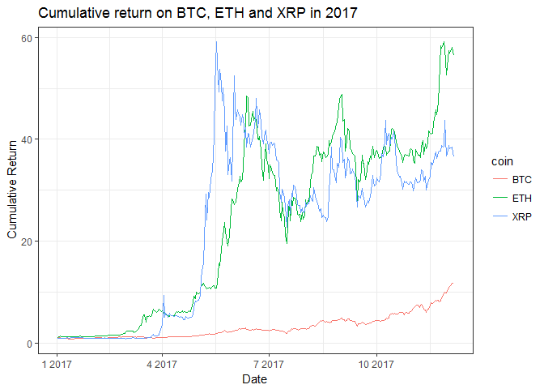

```r
# Preparing data for plotting together
cum_ret_coins2 <- cum_ret_coins %>%
    select(date, ret_cum_btc, ret_cum_eth, ret_cum_xrp) %>%
  rename(BTC = ret_cum_btc, ETH = ret_cum_eth, XRP = ret_cum_xrp) %>%
  gather(key ="coin", value = "cum_ret", BTC, ETH, XRP)



#Plot the cumulative returns
cum_ret_coins2 %>%
  ggplot(aes(x= date, y= cum_ret, color= coin)) +
  geom_line() +
  theme_bw() +
  labs(x="Date",
       y="Cumulative Return",
       title = "Cumulative return on BTC, ETH and XRP in 2017")
```

I will compared those currencies’ performance with Apple’s stock performance. Those currencies are traded every day including week-ends so observations are 339 for each currency. However, stocks are not traded on week-ends and holidays so the number of observations in AAPL is 215. I matched the date on Apple’s trading dates. The plot shows that even relatively low performance of Bitcoin has much higher returns compared to Apple’s stock.

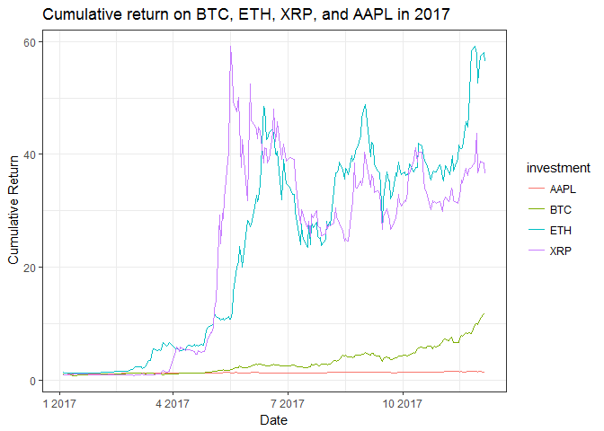

```r
# Calculating daily returns and cumulative returns for Apple stock as reference
AAPL_ret <- ret_func(AAPL)

# Merging four data-sets to compare cumulative returns between currencies and the stock
cum_ret_mixed <- cum_ret_coins %>%
    inner_join(AAPL_ret, by = "date") %>%
  select(date, ret_cum_btc, ret_cum_eth, ret_cum_xrp, ret_cum,
             ret_btc, ret_eth, ret_xrp, ret) %>%
  rename(ret_cum_AAPL = ret_cum, ret_AAPL = ret)

# Preparing data for plotting together
cum_ret_mixed2 <- cum_ret_mixed %>%
    select(date, ret_cum_btc, ret_cum_eth, ret_cum_xrp, ret_cum_AAPL) %>%
  rename(BTC = ret_cum_btc, ETH = ret_cum_eth, XRP = ret_cum_xrp,
             AAPL = ret_cum_AAPL) %>%
  gather(key ="investment", value = "cum_ret", BTC, ETH, XRP, AAPL)



#Plot the cumulative returns
cum_ret_mixed2 %>%
  ggplot(aes(x= date, y= cum_ret, color= investment)) +
  geom_line() +
  theme_bw() +
  labs(x="Date",
       y="Cumulative Return",
       title = "Cumulative return on BTC, ETH, XRP, and AAPL in 2017")
```

## Summary Statistics

In finance, high risk, high return. The more you take risks, the more you will get compensated (on average). There’s no free lunch. I will glimpse if this works. Standard deviation can be used as a proxy for risks (uncertainty; volatility). I will get some summary statistics on daily returns (not on cumulative returns). The daily returns of AAPL has the lowest daily mean return(0.18%) and the lowest standard deviation(0.0112). Those investment alternatives have a tendency that the riskier they are, the more returns they provide. However, XRP is riskier(more volatile) in terms of volatility (Std is 0.0984) but does not compensate enough (less mean return; 1.591%) for bearing that risk, compared to ETH. This is a crude analysis. Normally, in stocks, the risks could be divided into idiosyncratic risks and systematic risks (which can be diversified). Further analysis would be supplementary.

```r
cum_ret_mixed %>%
    select(ret_btc, ret_eth, ret_xrp, ret_AAPL) %>%
  rename(BTC = ret_btc, ETH = ret_eth, XRP = ret_xrp,
             AAPL = ret_AAPL) %>%
  gather(key ="investment", value = "daily_ret", BTC, ETH, XRP, AAPL) %>%
    group_by(investment) %>%
  summarize_each(funs(mean, sd, min, median, max), daily_ret) %>%
  knitr::kable(format = "markdown")
```

```
## `summarise_each()` is deprecated.
## Use `summarise_all()`, `summarise_at()` or `summarise_if()` instead.
## To map `funs` over a selection of variables, use `summarise_at()`
```

| investment | daily_ret_mean | daily_ret_sd | daily_ret_min | daily_ret_median | daily_ret_max |
| --- | --- | --- | --- | --- | --- |
| AAPL | 0.0017579 | 0.0111893 | -0.0387766 | 0.0007655 | 0.0609803 |
| BTC | 0.0092007 | 0.0480905 | -0.1663494 | 0.0104520 | 0.2354871 |
| ETH | 0.0159256 | 0.0714000 | -0.1924436 | 0.0040960 | 0.3014247 |
| XRP | 0.0159124 | 0.0984145 | -0.4588309 | -0.0023948 | 0.4703091 |